# GAMS: An Introduction

Author

Rick Dean

Abstract

Notes and completed tasks from the article [Generalised additive models (GAMs): an introduction](http://environmentalcomputing.net/intro-to-gams/) by Mitchell Lyons.

Load the Required R Packages:

```r
library(data.table)
library(ggplot2)
library(mgcv)
library(magrittr)
library(here)
library(gt)
library(magrittr)
library(RplotterPkg)
library(RregressPkg)
```

# 1 Generalized Additive Models (GAMS)

> Many data in the environmental sciences do not fit simple linear models and are best described by “wiggly models”; also known as Generalized Additive Models (GAMS).

## 1.1 GAMS in a nutshell

The linear model:
$$y = \beta_{0} + x_{1}\beta_{1} + \epsilon_{}, \space\epsilon \sim N(0,\sigma^{2})$$
What changes in a GAM is the presence of a smoothing term $f(x_{1})$.

$$y = \beta_{0} + f(x_{1}) + \epsilon, \space\epsilon \sim N(0,\sigma^{2})$$

## 1.2 A simple example

Create some sin wave shaped random data and plot.

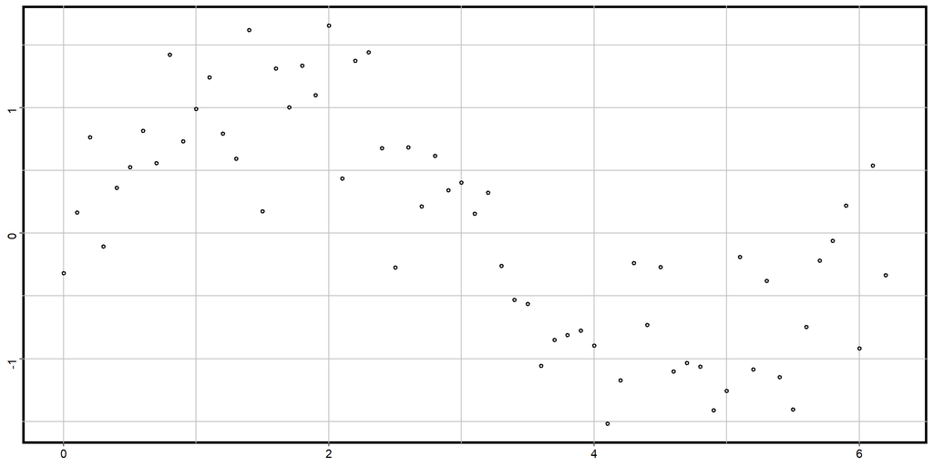

Sin wave shaped random data.

```r
set.seed(2)
x <- seq(0, pi * 2, 0.1)
sin_x <- sin(x)
y <- sin_x + rnorm(n = length(x), mean = 0, sd = sd(sin_x/2))
sample_data_dt <- data.table(
  x = x,
  y = y
)

RplotterPkg::create_scatter_plot(
  df = sample_data_dt,
  aes_x = "x",
  aes_y = "y"
)
```

From the *mgcv::* package create a GAM model of the data, summarize, and plot the model over the observations.

```r
gam_model <- mgcv::gam(y ~ s(x), method = "REML", data = sample_data_dt)

summary(gam_model)
```

```
Family: gaussian
Link function: identity

Formula:
y ~ s(x)

Parametric coefficients:
            Estimate Std. Error t value Pr(>|t|)
(Intercept)  0.03011    0.05428   0.555    0.581

Approximate significance of smooth terms:
       edf Ref.df     F p-value
s(x) 5.498   6.64 29.42  <2e-16 ***
---
Signif. codes:  0 '***' 0.001 '**' 0.01 '*' 0.05 '.' 0.1 ' ' 1

R-sq.(adj) =  0.758   Deviance explained =   78%
-REML = 45.419  Scale est. = 0.1856    n = 63
```

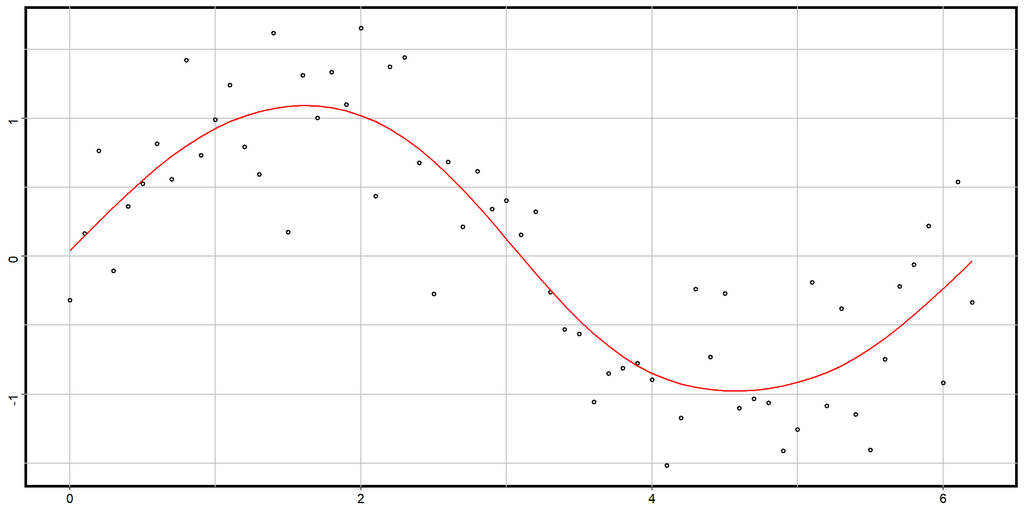

Sin wave shaped random data with fitted GAM model.

```r
sample_data_dt[, fit := gam_model$fitted.values]

RplotterPkg::create_scatter_plot(
  df = sample_data_dt,
  aes_x = "x",
  aes_y = "y"
) +
  geom_line(aes(y = fit), color = "red")
```

> The ‘edf’ is the estimated degrees of freedom - essentially, the larger the number, the more wiggly the fitted model. Values of around 1 tend to be close to a linear term.

Check the model fit.

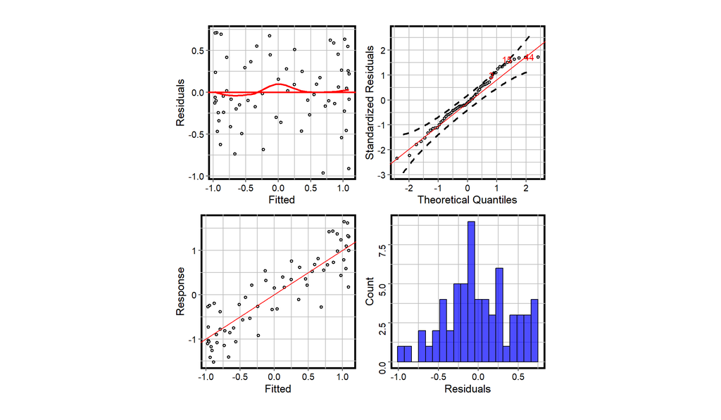

GAM model summary and check plot

```r
RregressPkg::plot_model_check(
  fitted_v = gam_model$fitted.values,
  response_v = sample_data_dt$y,
  residual_v = gam_model$residuals,
  histo_fill = "blue",
  histo_alpha = 0.7
)
```

## 1.3 Smooth terms

The smooth term $f(x_{1})$ is the sum of some number of functions:
$$f(x_{1}) = \sum b_{j}(x_{1})\beta_{j}$$
For j = 1 to k smooth terms.

From the GAM model obtain the term function values $b_{j}(x_{1})$ and sum the product of the model’s coefficients by these values to obtain the fitted values. Plot the fitted values and compare to the above model plot.

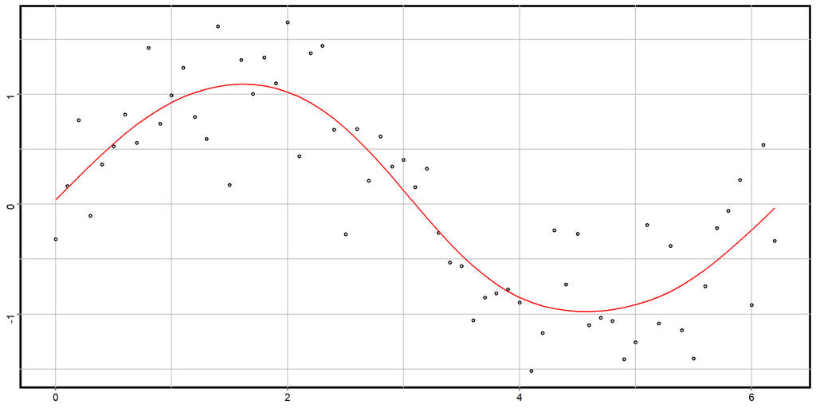

Sin wave shaped random data with calculated fit values from a GAM model.

```r
term_values <- mgcv::predict.gam(gam_model, type = "lpmatrix") # 63 x 10
model_coef <- gam_model$coefficients # 10 x 1
fitted_data <- term_values %*% model_coef

sample_data_dt[, fit2 := fitted_data]

RplotterPkg::create_scatter_plot(
  df = sample_data_dt,
  aes_x = "x",
  aes_y = "y"
) +
  geom_line(aes(y = fit2), color = "red")
```

Note that in this example there are 10 $k$ smooth terms including an intercept.

Plot the 9 individual term values (not including the intercept) that sum up to make the resulting fit.

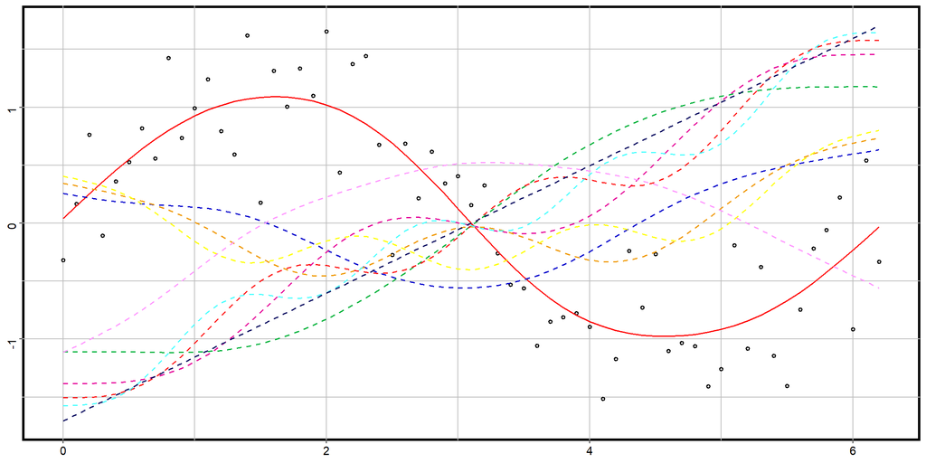

```r
dt <- cbind(sample_data_dt, term_values[,2:10])

RplotterPkg::create_scatter_plot(
  df = dt,
  aes_x = "x",
  aes_y = "y"
) +
  geom_line(aes(y = fit), color = "red") +
  geom_line(aes(y = `s(x).1`),linetype = "dashed", color = "#00B33C") +
  geom_line(aes(y = `s(x).2`),linetype = "dashed", color = "#0000CC") +
  geom_line(aes(y = `s(x).3`),linetype = "dashed", color = "#E60099") +
  geom_line(aes(y = `s(x).4`),linetype = "dashed", color = "#F09900") +
  geom_line(aes(y = `s(x).5`),linetype = "dashed", color = "#FF1919") +
  geom_line(aes(y = `s(x).6`),linetype = "dashed", color = "#FFFF00") +
  geom_line(aes(y = `s(x).7`),linetype = "dashed", color = "#4DFFFF") +
  geom_line(aes(y = `s(x).8`),linetype = "dashed", color = "#FF99FF") +
  geom_line(aes(y = `s(x).9`),linetype = "dashed", color = "#121464")
```

Plot the predictors’ model contribution to the response using *mgcv::plot(gam_model)*

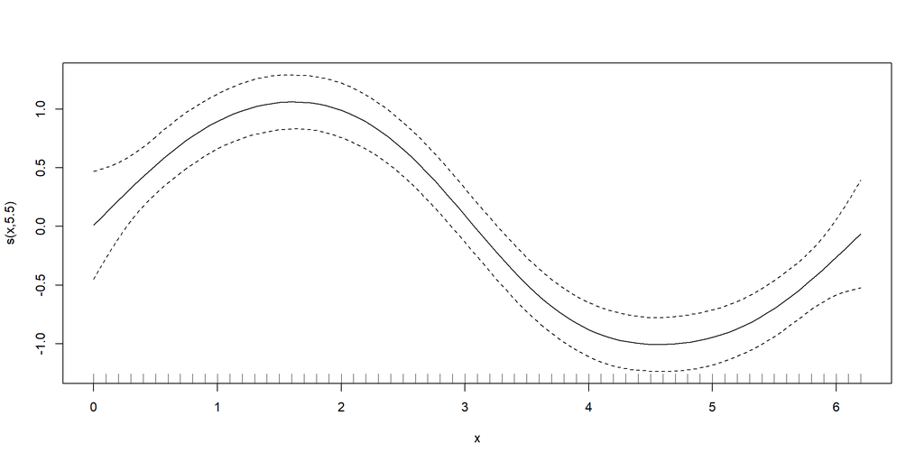

Predictors’ model contribution to the response using *mgcv::plot(gam_model)*

```r
mgcv::plot.gam(gam_model)
```

As an alternative, use *RgamPkg::plot_gam_1d(gam_model)* for a *ggplot2* based plot the predictor variable.

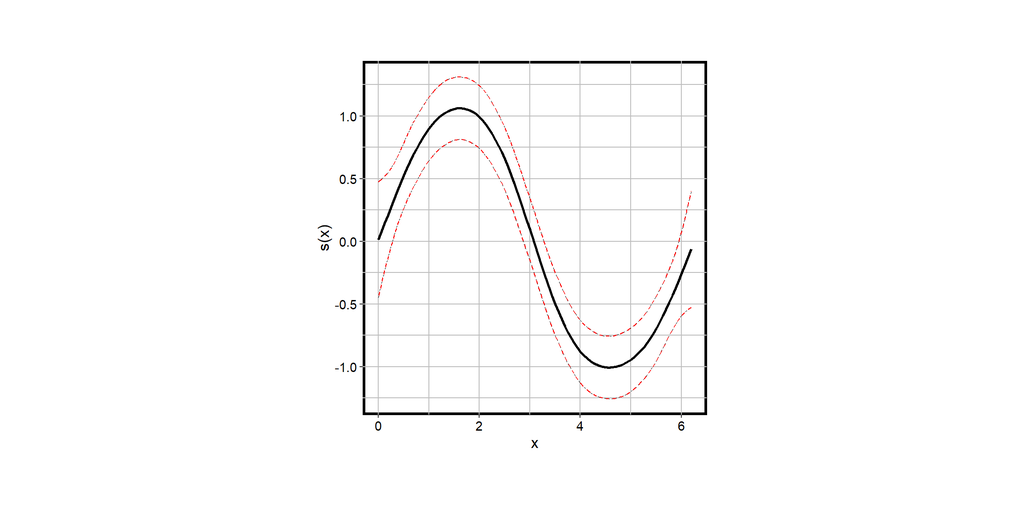

Predictors’ model contribution to the response using *RgamPkg::plot_gam_1d(gam_model)*

```r
RgamPkg::plot_gam_1d(
  gam_model = gam_model,
  columns = 1,
  col_width = 12,
  row_height = 12
)
```

## 1.4 A quick real example

Read in the CO2 data from Manua Loa and plot.

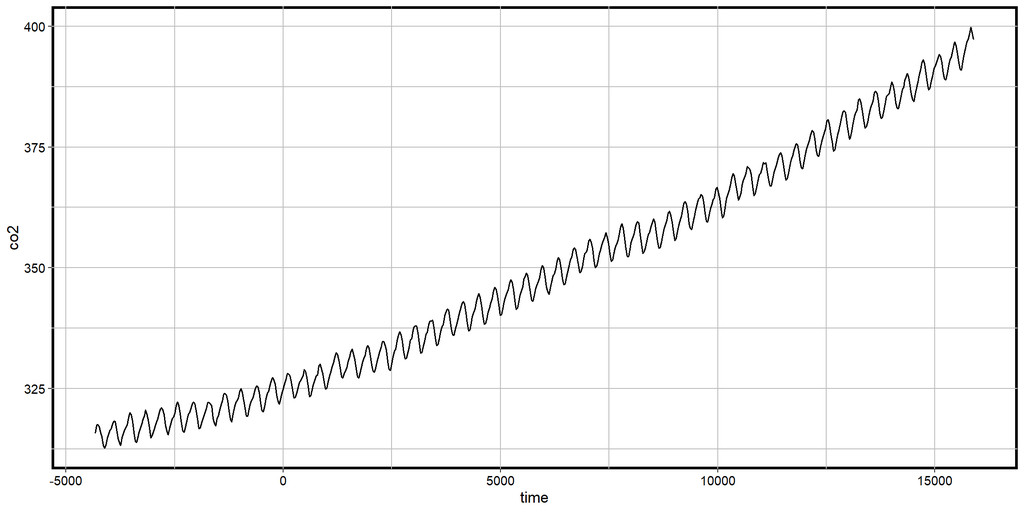

Manua Loa CO2 Data

```r
data_file_path <- file.path(here(), "articles", "Generalized additive models-an introduction","manua_loa_co2.csv")

co2_dt <- data.table::fread(data_file_path) %>%
  .[, time := as.integer(as.Date(Date, format = "%d/%m/%Y"))]

RplotterPkg::create_scatter_plot(
  df = co2_dt,
  aes_x = "time",
  aes_y = "co2",
  show_pts = FALSE,
  connect = TRUE,
  rot_y_tic_label = TRUE,
  x_title = "time",
  y_title = "co2"
)
```

Fit a simple GAM model with a single smooth term for *time* and plot the predicted values from this term between the years 2000 to 2010.

$$y = \beta_{0} + f_{trend}(time) + \epsilon, \space\epsilon \sim N(0, \sigma^{2})$$

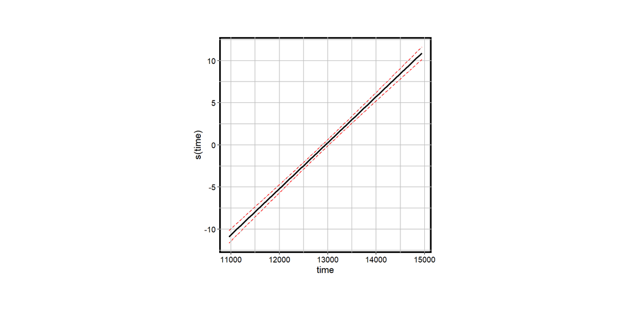

GAM model that predicts co2 values from *time* term, 2000 to 2010

```r
co2_2000_2010_dt <- co2_dt[year %in% 2000:2010,]
co2_time_gam <- mgcv::gam(co2 ~ s(time), data = co2_2000_2010_dt, method = "REML")
co2_time_gam_summary <- summary(co2_time_gam)

RgamPkg::plot_gam_1d(
  gam_model = co2_time_gam,
  columns = 1,
  col_width = 12,
  row_height = 12
)
```

Note how the smooth term actually reduces to a ‘normal’ linear term with a edf of 1.0004188.

Check the model’s fit.

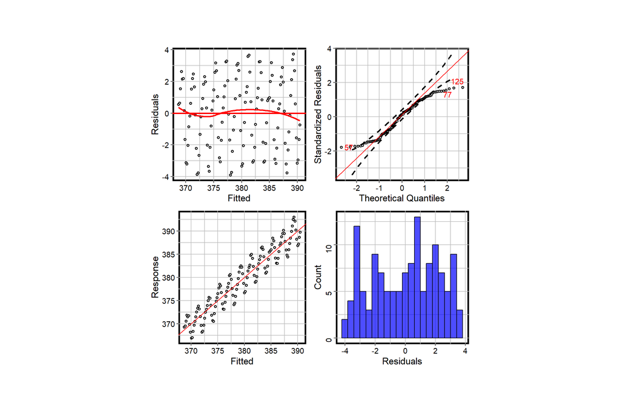

Check on GAM model fit co2 ~ s(time)

```r
RregressPkg::plot_model_check(
  fitted_v = co2_time_gam$fitted.values,
  response_v = co2_2000_2010_dt$co2,
  residual_v = co2_time_gam$residuals,
  histo_fill = "blue",
  histo_alpha = 0.7
)
```

> The residual plots have a very odd looking rise-and-fall pattern… Let’s try again, and introduce something called a cyclical smoother.

$$y = \beta_{0} + f_{intrannual}(month) + f_{trend}(time) + \epsilon, \space\epsilon \sim N(0, \sigma^{2})$$
The cyclical smooth term, $f_{intrannual}(month)$ is comprised of basis functions just the same as we have seen already, except that the end points of the spline are contrained to be equal - which makes sense when we’re modelling a variable that is cyclical (across month/years).

We’ll now see the *bs* argument to choose the type of smoother, and the *k* argument to choose the number of knots, because cubic regression splines have a set number of knots. We use 12 knots, because there are 12 months/year.

Add a cubic cyclical term to the model and plot model’s terms with the response.

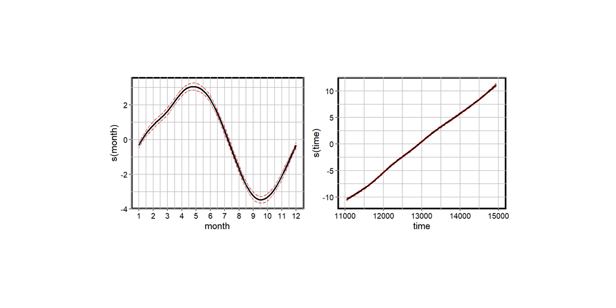

Cyclical and trend GAM model and their contribution to the co2 response.

```r
co2_season_time_gam <- mgcv::gam(co2 ~ s(month, bs = "cc", k = 12) + s(time), data = co2_2000_2010_dt, method = "REML")

RgamPkg::plot_gam_1d(
  gam_model = co2_season_time_gam,
  col_width = 10,
  row_height = 8,
  x_major_breaks = list(
    `s(month)` = seq(1, 12, 1),
    `s(time)` = seq(11000, 15000, 1000)
  )
)
```

Check the model’s fit.

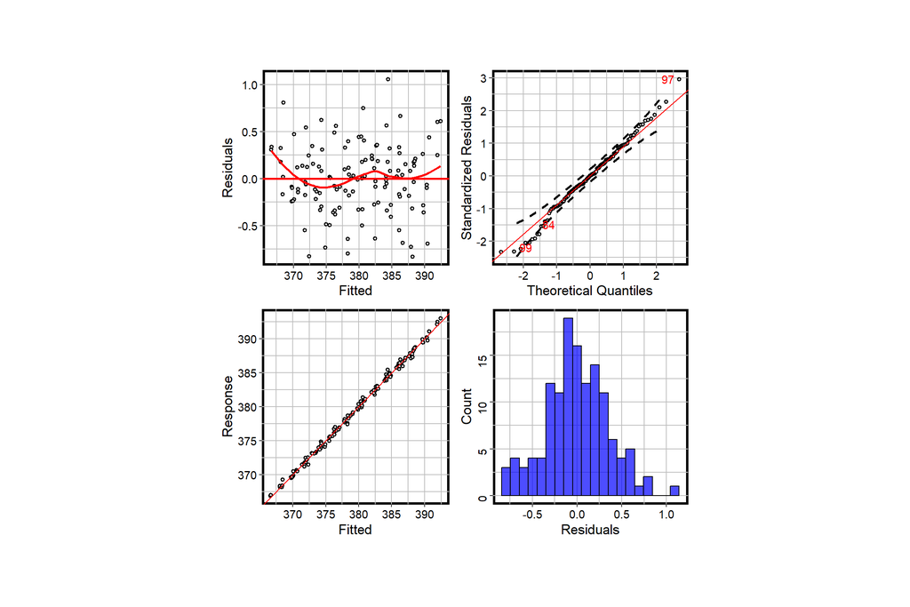

Check on GAM model fit co2 ~ s(month, bs = ‘cc’, k = 12) + s(time)

```r
RregressPkg::plot_model_check(
  fitted_v = co2_season_time_gam$fitted.values,
  response_v = co2_2000_2010_dt$co2,
  residual_v = co2_season_time_gam$residuals,
  histo_fill = "blue",
  histo_alpha = 0.7
)
```

## 1.5 Communicating the results

Plot the final GAM model over the observed data.

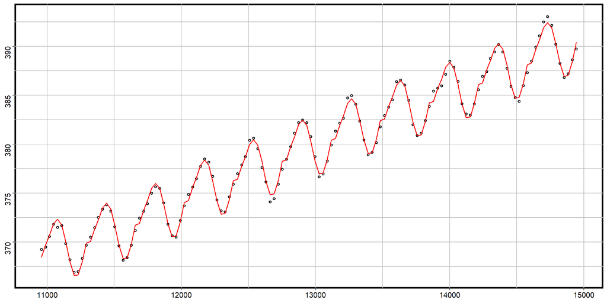

```r
co2_2000_2010_dt[, fit := co2_season_time_gam$fitted.values]

RplotterPkg::create_scatter_plot(
  df = co2_2000_2010_dt,
  aes_x = "time",
  aes_y = "co2"
) +
  geom_line(aes(y = fit), color = "red")
```